# Lab4

```python
import numpy as np
import matplotlib
import matplotlib.pyplot as plt
import scipy
from scipy import stats
import h5py
```

```python
hf = h5py.File('Shared/gammaray_lab4.h5', 'r')
```

```python
hf.keys()
```

```
<KeysViewHDF5 ['data']>
```

```python
data = np.array(hf.get('data'))
```

```python
np.shape(data)
```

```
(4, 25920001)
```

```python
data[:,0]
```

```
array([9.40680016e+08, 3.15000000e+02, 4.50000000e+01, 1.00000000e+01])
```

```python
hf.close()
```

```python
print("Minimum particle count:", np.min(data[3, :]))
print("Maximum particle count:", np.max(data[3, :]))
print("Average particle count:", np.mean(data[3, :]))
```

```
Minimum particle count: 0.0
Maximum particle count: 30.0
Average particle count: 7.09730524315952
```

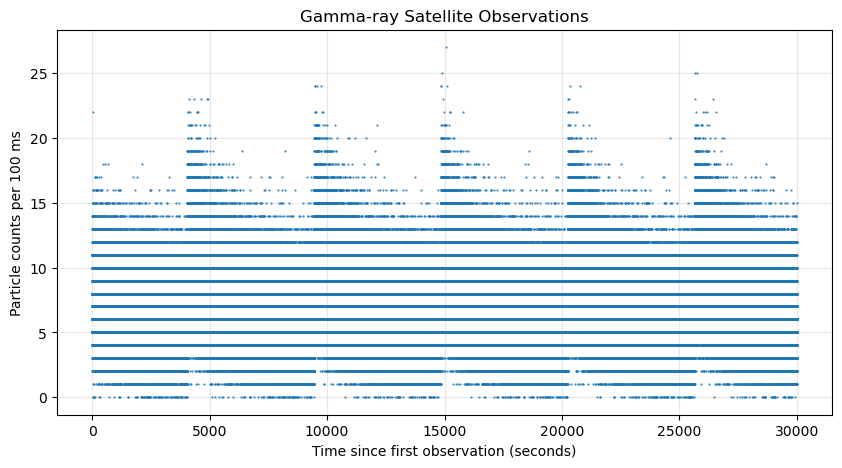

```python
t = data[0, :300000]
counts = data[3, :300000]

time = t - t[0]

plt.figure(figsize=(10, 5))
plt.plot(time, counts, '.', markersize=1)

plt.xlabel('Time since first observation (seconds)')
plt.ylabel('Particle counts per 100 ms')
plt.title('Gamma-ray Satellite Observations')
plt.grid(alpha=0.3)

plt.show()
```

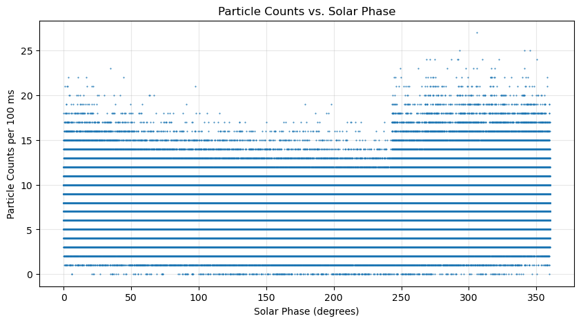

```python
solar_phase = data[1, :300000]
counts = data[3, :300000]

plt.figure(figsize=(10, 5))
plt.plot(solar_phase, counts, '.', markersize=1)

plt.xlabel('Solar Phase (degrees)')
plt.ylabel('Particle Counts per 100 ms')
plt.title('Particle Counts vs. Solar Phase')
plt.grid(alpha=0.3)

plt.show()
```

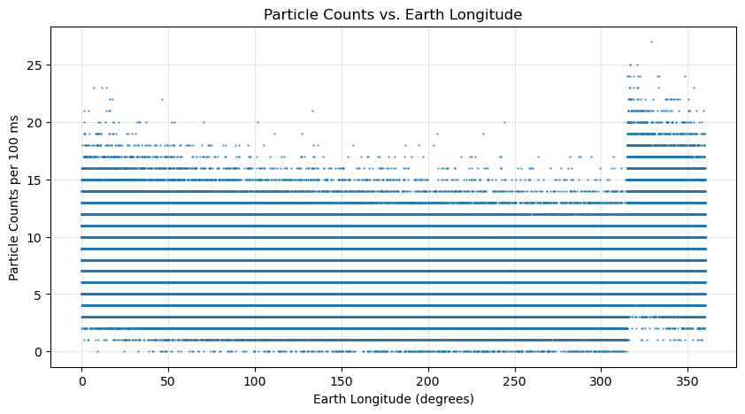

```python
longitude = data[2, :300000]
counts = data[3, :300000]

plt.figure(figsize=(10, 5))
plt.plot(longitude, counts, '.', markersize=1)

plt.xlabel('Earth Longitude (degrees)')
plt.ylabel('Particle Counts per 100 ms')
plt.title('Particle Counts vs. Earth Longitude')
plt.grid(alpha=0.3)

plt.show()
```

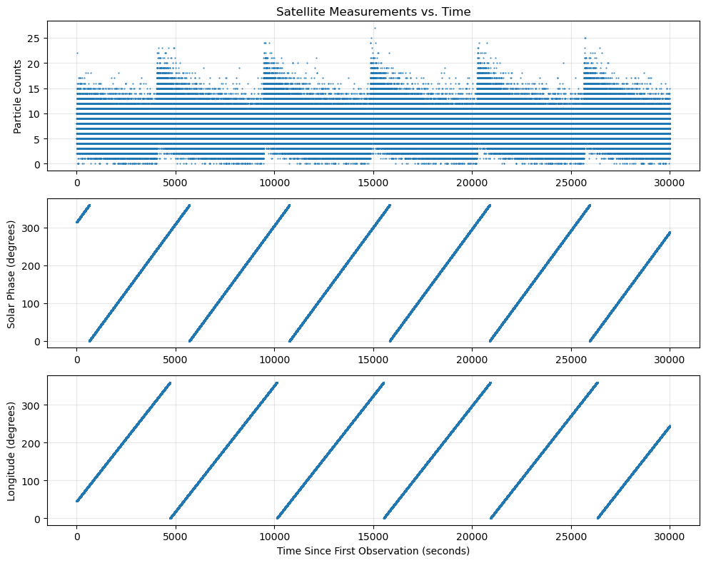

```python
time = data[0, :300000] - data[0, 0]
solar_phase = data[1, :300000]
longitude = data[2, :300000]
counts = data[3, :300000]

plt.figure(figsize=(10, 8))

plt.subplot(3, 1, 1)
plt.plot(time, counts, '.', markersize=1)
plt.ylabel('Particle Counts')
plt.title('Satellite Measurements vs. Time')
plt.grid(alpha=0.3)

plt.subplot(3, 1, 2)
plt.plot(time, solar_phase, '.', markersize=1)
plt.ylabel('Solar Phase (degrees)')
plt.grid(alpha=0.3)

plt.subplot(3, 1, 3)
plt.plot(time, longitude, '.', markersize=1)
plt.xlabel('Time Since First Observation (seconds)')
plt.ylabel('Longitude (degrees)')
plt.grid(alpha=0.3)

plt.tight_layout()
plt.show()
```

#### Question 1

The time plots also show brief periods of elevated particle counts that repeat approximately every 5,400 seconds, which matches the satellite's 90-minute orbital period. This suggests that much of the variation is related to the satellite's orbit rather than random fluctuations alone.

There is some potential for signal contamination in the data, since unusually high particle counts could include gamma-ray bursts. However, the regularly repeating increases are more likely associated with the changing background than with individual bursts. I cannot identify any specific GRBs from these plots alone.

To construct a background probability distribution, I plan to use a Poisson distribution as a starting point, since we are counting individual particle detections. Because the background changes with time, I would estimate the expected count at different points within the approximately 5,400-second orbit rather than assuming one constant mean.

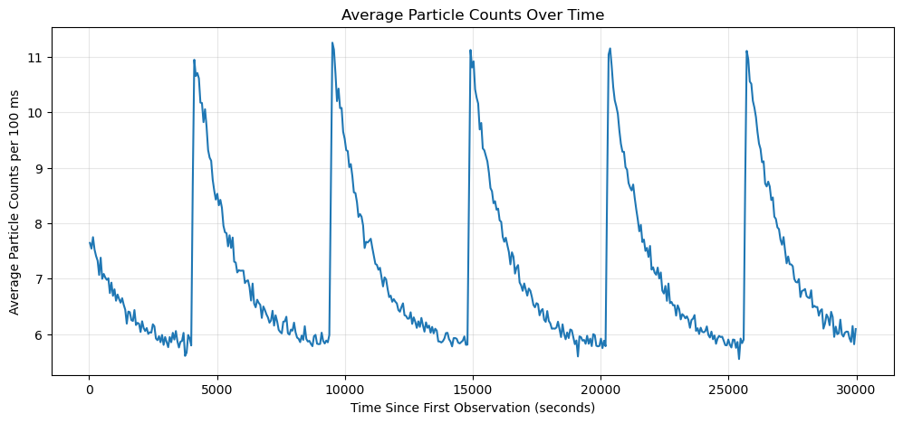

```python
time = data[0, :300000] - data[0, 0]
counts = data[3, :300000]

avg_time = []
avg_counts = []

for i in range(0, len(counts), 600):
    avg_time.append(np.mean(time[i:i+600]))
    avg_counts.append(np.mean(counts[i:i+600]))

plt.figure(figsize=(12, 5))
plt.plot(avg_time, avg_counts)

plt.xlabel('Time Since First Observation (seconds)')
plt.ylabel('Average Particle Counts per 100 ms')
plt.title('Average Particle Counts Over Time')
plt.grid(alpha=0.3)

plt.show()
```

#### Question 2

The background varies periodically with the satellite's orbit. After averaging the particle counts into one-minute intervals, I found that the background follows a repeating pattern approximately every 5,400 seconds, or 90 minutes. The average count gradually decreases from approximately 11 to 6 particles per 100 milliseconds, then rises sharply back to about 11 before gradually decreasing again. The pattern repeats consistently over the five orbits shown in the plot. This suggests that the background is strongly influenced by the satellite's orbital motion.

```python
period = 5400

time = data[0, :] - data[0, 0]
counts = data[3, :]

folded_time = time % period
```

```python
bins = np.arange(0, 5401, 60)
bin_centers = (bins[:-1] + bins[1:]) / 2

total_counts, _ = np.histogram(
    folded_time, bins=bins, weights=counts)

measurements, _ = np.histogram(
    folded_time, bins=bins)

mean_counts = total_counts / measurements
```

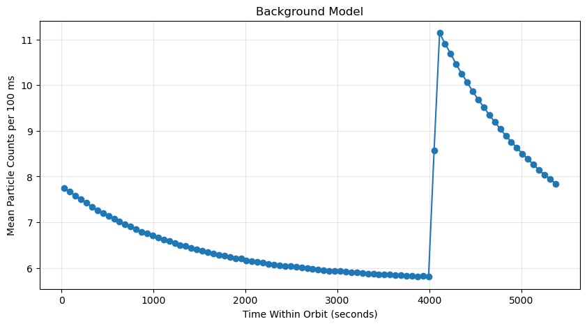

```python
plt.figure(figsize=(10, 5))

plt.plot(bin_centers, mean_counts, 'o-')

plt.xlabel('Time Within Orbit (seconds)')
plt.ylabel('Mean Particle Counts per 100 ms')
plt.title('Background Model')
plt.grid(alpha=0.3)

plt.show()
```

```python
bin_number = 50

start = bins[bin_number]
end = bins[bin_number + 1]

observed_counts = counts[
    (folded_time >= start) & (folded_time < end)]

expected_mean = mean_counts[bin_number]

print(f"Expected mean: {expected_mean:.3f}")
print(f"Number of observations: {len(observed_counts)}")
```

```
Expected mean: 5.925
Number of observations: 288000
```

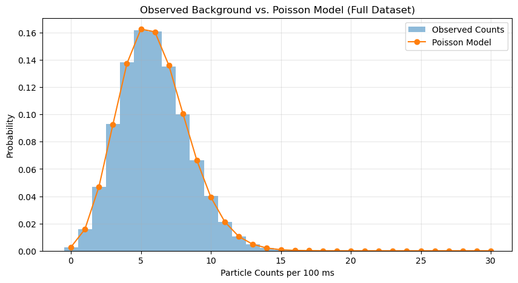

```python
n = np.arange(0, 31)

plt.figure(figsize=(10, 5))

plt.hist(
    observed_counts,
    bins=np.arange(-0.5, 30.5, 1),
    density=True,
    alpha=0.5,
    label='Observed Counts')

plt.plot(
    n,
    stats.poisson.pmf(n, expected_mean),
    'o-',
    label='Poisson Model')

plt.xlabel('Particle Counts per 100 ms')
plt.ylabel('Probability')
plt.title('Observed Background vs. Poisson Model (Full Dataset)')
plt.legend()
plt.grid(alpha=0.3)

plt.show()
```

#### Question 3

To evaluate the model, I selected the 60-second interval from 3,000 to 3,060 seconds within each orbit and combined the observations from that interval across the entire 30-day dataset. I compared the resulting particle-count histogram with a Poisson distribution using the expected background for that orbital phase. The two distributions agreed closely.

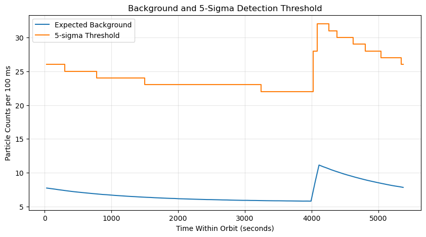

```python
p_5sigma = stats.norm.sf(5)

thresholds = stats.poisson.isf(p_5sigma, mean_counts) + 1

plt.figure(figsize=(10, 5))

plt.plot(bin_centers, mean_counts, label='Expected Background')
plt.step(bin_centers, thresholds, where='mid',
         label='5-sigma Threshold')

plt.xlabel('Time Within Orbit (seconds)')
plt.ylabel('Particle Counts per 100 ms')
plt.title('Background and 5-Sigma Detection Threshold')
plt.legend()
plt.grid(alpha=0.3)

plt.show()
```

#### Question 4

The threshold varies from approximately 22 particles per 100 milliseconds during the lowest-background portion of the orbit to 32 particles during the highest-background portion. The threshold follows the same general pattern as the expected background, decreasing gradually before increasing sharply around 4,000 seconds into the orbit. This demonstrates why a constant detection threshold would be inappropriate. An observation that qualifies as a five-sigma detection during a low-background period might not be significant during a high-background period.

#### Question 5

My initial thought is that the background variation could be partially caused by Earth blocking radiation from the Sun or other regions of the sky as the satellite orbits. The gradual decrease in particle counts followed by a sharp increase could indicate a changing amount of radiation reaching the detector as a source becomes obscured and later reappears. However, cosmic rays arrive approximately isotropically, making the occultation of a single source less likely.

Another possible explanation is the interaction of charged cosmic rays with Earth's magnetic field. The magnetic field can deflect incoming charged particles, and the effectiveness of this shielding varies with the satellite's position. The South Atlantic Anomaly is a region where Earth's magnetic field is relatively weak, allowing energetic charged particles from Earth's radiation belts to reach lower altitudes.

I propose that the satellite's changing exposure to these particles contributes to the periodic variation in its background count rate. The data show a much sharper transition than one would expect from a magnetic-field structure, suggesting that the effect may have been simplified for the simulation.

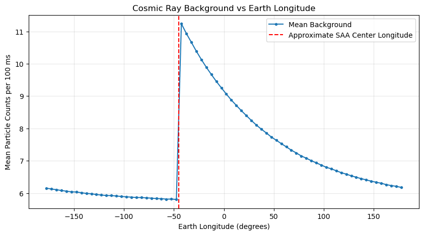

```python
longitude = data[2, :]
counts = data[3, :]

longitude = (longitude + 180) % 360 - 180

lon_bins = np.arange(-180, 181, 5)
lon_centers = (lon_bins[:-1] + lon_bins[1:]) / 2

total_counts, _ = np.histogram(
    longitude, bins=lon_bins, weights=counts)

measurements, _ = np.histogram(
    longitude, bins=lon_bins)

mean_lon_counts = np.divide(
    total_counts, measurements,
    out=np.full(len(total_counts), np.nan),
    where=measurements > 0)

plt.figure(figsize=(10, 5))

plt.plot(lon_centers, mean_lon_counts, 'o-',
         markersize=3, label='Mean Background')

plt.axvline(-45, color='red', linestyle='--',
            label='Approximate SAA Center Longitude')

plt.xlabel('Earth Longitude (degrees)')
plt.ylabel('Mean Particle Counts per 100 ms')
plt.title('Cosmic Ray Background vs Earth Longitude')
plt.legend()
plt.grid(alpha=0.3)

plt.show()
```

I was curious to see if the data actually aligned with the SAA and it does. This makes me confident that, at least for this simulated data, that this is casued by the SAA.